# Exploratory Analysis

Global food waste: Arnav Mohan (arnmoh18@uw.edu), Alex Hsu (ahsu4@uw.edu), Mohamed Aden (moaden@uw.edu)

## Global Food Waste Data Analysis

### Authors

Arnav Mohan (arnmoh18@uw.edu), Alex Hsu (ahsu4@uw.edu), Mohamed Aden (moaden@uw.edu)

https://github.com/info-201b-sp24/exploratory-analysis-arnmoh18

### Date

May 17, 2024

### Abstract

Through our project we plan to analyze global data on food waste to learn about how food production and consumption practices can be improved to reduce food waste. Our goal is to find practices that are the most and least efficient to help create better policies, laws, and methods to cut down our food waste.

## Keywords

1. Food Waste
2. Global
3. Disparities
4. Prevention

### Introduction

-How does food wastefulness differ between countries worldwide?  
-What could be contributing to wastefulness  
-How do we track food waste?  
-Where does food wastefulness occur?  
-How do we counter missing data around food waste?  
We would like to highlight the severity of food wastefulness by investigating and finding relevant information and data regarding food wastefulness in hopes of presenting the data in some way that viewers can understand not only how big of an issue this is, but also feel make these viewers feel inspired to possibly take action through whatever actions they can (sharing this information with others to educate them is just one example). The motivation behind our research questions is to gain a better understanding of the true scale of food wastefulness, each with a separate motive. The first question serves to answer the disparities in food wastefulness between different parts of the world (i.e. what areas waste the most food, how does this area waste food compared to another, etc), and leads to ask the next research question of what could be contributing to food wastefulness which aims to find what factors could be attributed to food wastefulness in some areas. Tracking where food wastefulness occurs is also extremely important as we want to focus our research on areas where the issue is the most relevant. We hope to do enough data analysis to answer these questions with hopes of using data to prove a point of why it matters, what can be done to combat this issue, and above all, to effectively represent the true extent of food waste. Helping people understand this is a bigger issue will bring attention to this issue, which we hope will also bring positive change within this domain.

### Related Work

> Food wastefulness is an issue that is bigger than most believe it to be. In our own context here in the US, approximately 38% (Feeding America) of all the food produced for consumption is wasted yearly, yet, there’s not much of an initiative or more accurately, not much urgency for change in terms of reducing wastefulness. This is an issue that will only get bigger as the world population grows, so does the need for more food, which in turn will also mean more food waste. Food waste is different from food loss; “Food ‘loss’ occurs before the food reaches the consumer as a result of issues in the production, storage, processing, and distribution phases”(Food Waste), so this would be mostly during production and transportation of the food (lost food on farms, in-transit, food in storage, etc). As for food waste, here’s a definition: “Food ‘waste’ refers to food that is fit for consumption but consciously discarded at the retail or consumption phases”(Ishangulyyev et al.), this could be food in households, in restaurants, or any other setting past the production/transportation process–in other terms, once the food has settled in it’s target location (for example, some vegetation on a farm might have a target location of a restaurant where it may end up, so the restaurant is where it settles in this case). For our project, we will be solely focusing on food waste.  
> Citations:  
> -“Fighting Food Waste and Hunger with Food Rescue.” Feeding America. Accessed 30 Apr. 2024.  
> -“Food Waste.” The Nutrition Source, 30 Nov. 2022,.  
> -Ishangulyyev, Rovshen, et al. “Understanding Food Loss and Waste-Why Are We Losing and Wasting Food?” Foods (Basel, Switzerland), U.S. National Library of Medicine, 29 July 2019.

### The Dataset

> Where did you find the data? Please include a link to the data source  
> https://www.fao.org/platform-food-loss-waste/flw-data/en/

> Who collected the data?  
> Food and Agricultural Organization of the United States

> How was the data collected or generated?  
> The data was collected and generated through an extensive review of literature in the public domain conducted by the FAO. This review process involved gathering data and information from almost 500 publications, reports, and studies. These sources included a variety of organizations such as the World Bank, GIZ, FAO, IFPRI, and more. This comprehensive approach allowed for a broad and diverse collection of data to monitor the state of food loss.

> Why was the data collected?  
> The data was collected to understand the extent of food loss and waste across different stages of the supply chain. This information is crucial for identifying areas where interventions are needed to reduce food loss and waste. The data also serves as a basis for the Sustainable Development Goals (SDG) process in the absence of actual data.

> How many observations (rows) are in your data?  
> 25417

> How many features (columns) are in the data?  
> 18

> What, if any, ethical questions or questions of power do you need to consider when working with this data?  
> When working with this data, it’s important to consider the potential biases in the data collection process. For instance, national estimates may underrepresent the issue of food loss, while studies with small sample sizes may not be fully representative. There may also be biases in the data collected at the national level and within individual studies. Furthermore, the power dynamics between different stakeholders in the food supply chain could influence the data collection and reporting processes.

> What are possible limitations or problems with this data?  
> There are several limitations with the data collected on food loss and waste. One issue is the summation of loss percentages across the supply chain, which can inflate the overall percentage losses. The representativeness of the data is also a concern. National estimates may under-represent the issue of food loss, while studies with small sample sizes may overrepresent it. The data also shows variability in estimates along different stages of the value chains and regions, making an average estimate less practical. Comparability of data is another challenge due to different measurement practices and methods, and estimates that may not be repeated over time. Potential biases in the data collected, both at the national level and within individual studies, can also skew the results. In the case studies, the sample sizes may not be large enough to find causes and solutions through such a generalized collection of data. The inconsistency in the available data shows the need to measure losses carefully and with reliable and consistent methods. There are gaps in the data by country, commodity, and for entire tracts of the supply chain. These limitations are the need for more reliable methods of data collection and the importance of increasing the quality and quantity of available data.

### Limitations & Challenges

> The possible implications based on data around tracking food waste would show that there are systems in place that are not properly tracking food waste around the world. A lot of food waste data assumes that the waste goes to trash cans or waste bins but a lot of it is also left in the environment where it is found by animals. It would also make implications around how food is handled by policymakers that advocate for a better environment and the legal work that would need to be done to enforce less food waste. Furthermore it would make implications for the food industry on how to price or what proportions they would need to make for food based on the amount of food waste data that is being collected. Not to mention it would also make implications on how technologists need to improve their methods around creating technology or design products that prevent or discourage more food waste.

### Summary Information

When looking at the data we first decided to take a look at what type of food had the highest and lowest rate of food waste since that can effect the amount of food waste. We noticed that the foods with the highest amount of food waste were broccoli, cauliflowers, and strawberries at 65 percent. Furthermore we also noticed that the food with the lowest amount of food waste turned out to be goats at 0.12 percent.

### Table

```
## # A tibble: 827 × 3
## # Groups:   country [123]
##    country                     commodity                       max_loss
##    <chr>                       <chr>                              <dbl>
##  1 Australia                   Cauliflowers and broccoli           65
##  2 Republic of Korea           Strawberries                        65
##  3 United States of America    Papayas                             64
##  4 United Republic of Tanzania Mangoes, guavas and mangosteens     63
##  5 United States of America    Carrots and turnips                 63
##  6 India                       Eggplants (aubergines)              62.5
##  7 United States of America    Mustard seed                        61.1
##  8 Viet Nam                    Rice                                60
##  9 Uganda                      Maize (corn)                        59.5
## 10 Kenya                       Maize (corn)                        55.7
## # ℹ 817 more rows
```

| country | commodity | max_loss |
| --- | --- | --- |
| Australia | Cauliflowers and broccoli | 65.00 |
| Republic of Korea | Strawberries | 65.00 |
| United States of America | Papayas | 64.00 |
| United Republic of Tanzania | Mangoes, guavas and mangosteens | 63.00 |
| United States of America | Carrots and turnips | 63.00 |
| India | Eggplants (aubergines) | 62.50 |
| United States of America | Mustard seed | 61.10 |
| Viet Nam | Rice | 60.00 |
| Uganda | Maize (corn) | 59.48 |
| Kenya | Maize (corn) | 55.70 |
| Trinidad and Tobago | Pumpkins, squash and gourds | 55.00 |
| Burkina Faso | Maize (corn) | 54.05 |
| Ghana | Cabbages | 54.00 |
| Benin | Maize (corn) | 53.90 |
| Benin | Tomatoes | 53.00 |
| Benin | Oranges | 51.00 |
| Ghana | Tomatoes | 50.50 |
| Australia | Lettuce and chicory | 50.00 |
| Australia and New Zealand | Snails, fresh, chilled, frozen, dried, salted or in brine, except sea snails | 50.00 |
| Benin | Mangoes, guavas and mangosteens | 50.00 |
| Benin | Pineapples | 50.00 |
| Canada | Snails, fresh, chilled, frozen, dried, salted or in brine, except sea snails | 50.00 |
| China | Onions and shallots, green | 50.00 |
| Guatemala | Maize (corn) | 50.00 |
| Haiti | Mangoes, guavas and mangosteens | 50.00 |
| Kenya | Bananas | 50.00 |
| Nepal | Tangerines, mandarins, clementines | 50.00 |
| United Republic of Tanzania | Tomatoes | 50.00 |
| United States of America | Snails, fresh, chilled, frozen, dried, salted or in brine, except sea snails | 50.00 |
| Zimbabwe | Cow peas, dry | 49.70 |

[output cut: 797 more lines]

This table shows the maximum percentage loss of various commodities in different countries, indicating the challenges faced in agricultural production and food security.

### Chart 1

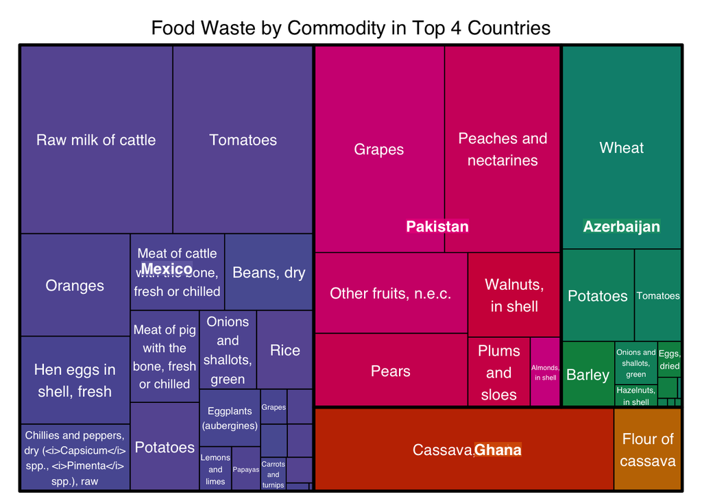

### Purpose

This tree map visualizes the total food waste by commodity for the top 4 countries with the most waste. The size of each box represents the total loss of each commodity in each country.

### Insights

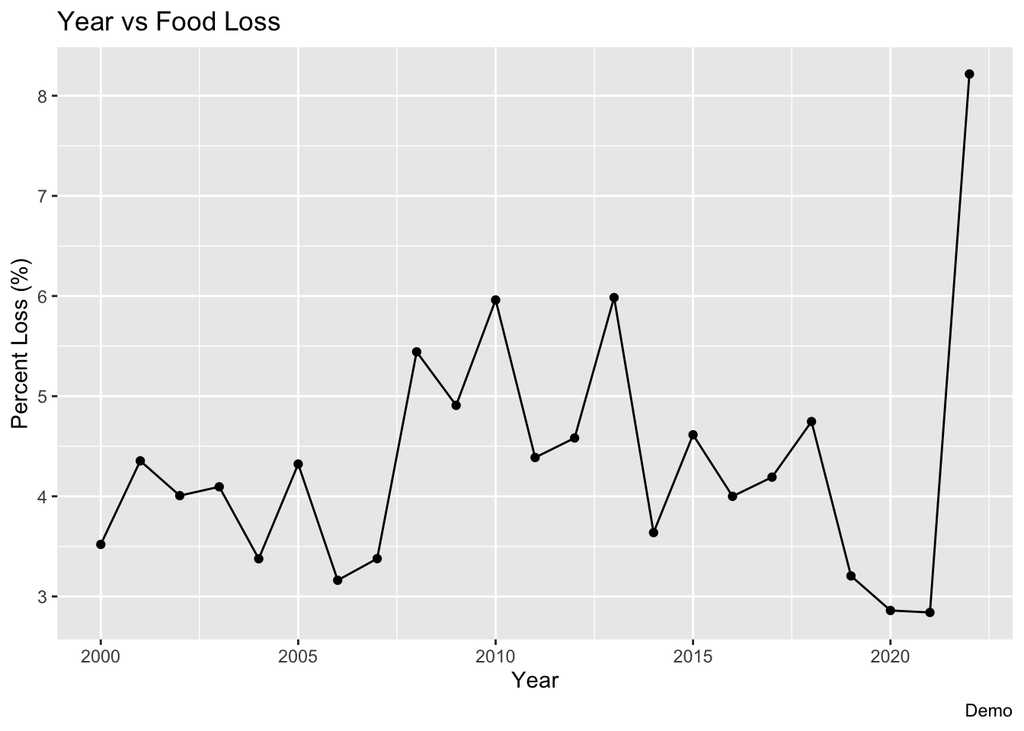

### Purpose

Through aggregating the data by year, we are able to gain insights on food waste trends over a given time period

### Chart 3

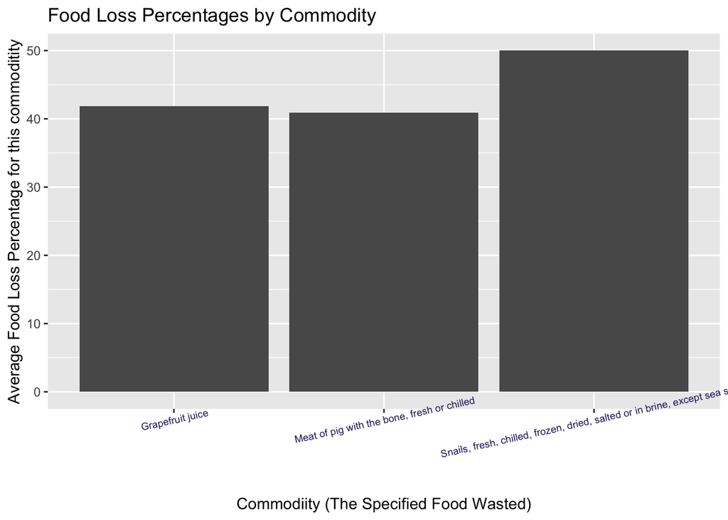

[figure not shown]

### Purpose

We were curious as to what commodities specifically were experiencing the highest loss percentages (irregardless of location or year) as well as if there is a significant difference in the top three percentages for commodities. These percentages are based on food produced and food lost after production somewhere in the process of the preparation and distribution of the produced commodities (harvesting, storing, drying, transporting, winnowing, etc) and the combination of these percentages with commodities will help us to answer questions such as what the highest average food loss percentages are, what commodities are wasted most and several other questions regarding commodities and their losses post-production.

### Insights

Simply looking at the fact that the top three commodities are foods that are not too common. Grapefruit juice, meat of the pig w/the bone, and snails (in various forms excluding sea snails), are not foods that are typically eaten on a day to day. This alone suggests not only that these foods are less desired, but also that expectations prior to production were much higher than they turned out to be. All three of these commodities have around a 40-50% average food loss meaning a large portion of these commodities being produced were not accurately produced in scale due to some miscalculation when determining how much to produce.